# Tutorial 3 - Yu et al., 2022

## 1.4 Model the Data Generation Process

First, let’s define the functions

```r
harm = function(shocksLarger, shocksSmaller){
  return(shocksLarger - shocksSmaller)
}

payout = function(moneyLarger, moneySmaller){
  return(moneyLarger - moneySmaller)
}
```

```r
example = data.frame(moneyMore = 10, moneyLess = 0, shocksMore = 8, shocksLess = 5)
example
```

```
##   moneyMore moneyLess shocksMore shocksLess
## 1        10         0          8          5
```

Now we can view the outputs of this example to make sure they look correct:

```r
harm(example$shocksMore[1], example$shocksLess[1])
```

```
## [1] 3
```

```r
payout(example$moneyMore[1], example$moneyLess[1])
```

```
## [1] 10
```

So the choice for more has 3more harm for 10 more money: that’s correct.

## 1.5 Simulating Data

Now let’s preallocate and define functions, trial list, and parameters

```r
trialList = data.frame(Left = rep(c(T, F), 100),
                       MoneyA = rep(rep(seq(11, 20), each = 10), times = 2),
                       MoneyB = 10,
                       ShocksA = 10,
                       ShocksB = rep(rep(seq(0, 9), times = 10), times = 2))
head(trialList)
```

```
##    Left MoneyA MoneyB ShocksA ShocksB
## 1  TRUE     11     10      10       0
## 2 FALSE     11     10      10       1
## 3  TRUE     11     10      10       2
## 4 FALSE     11     10      10       3
## 5  TRUE     11     10      10       4
## 6 FALSE     11     10      10       5
```

```r
utility = function(Payout, Harm, kappa){
  return((Payout * kappa) - (Harm * (1 - kappa)))
}

probability = function(beta, epsilon, gamma, utilitydiff, isLeft){
  prob = 1 / (1 + exp(-(beta * utilitydiff)))
  prob = prob * (1 - 2 * epsilon) + epsilon
  if (isLeft) {
    prob = prob + gamma * (2 * epsilon)
  } else {
    prob = prob - gamma * (2 * epsilon)
  }
  return(prob)
}

freeParameters = data.frame(kappa = rep(seq(0, 0.95, 0.05), times = 60) +
                              sample(seq(0, 0.05, 0.001), 20*6*10, replace = T),
                            beta = sample(seq(0,100), 20*6*10, replace = T),
                            epsilon = rep(rep(seq(0, 0.5, 0.1), times = 10),
                                          each = 20),
                            gamma = rep(seq(-0.5, 0.4, 0.1), each = 20*6) +
                              sample(seq(0, 0.1, 0.001), 20*6*10, replace = T))
predictions = data.frame()
```

Now that all of that’s done, let’s generate predictions

```r
for (i in 1:length(freeParameters[,1])){
  Kappa = freeParameters[i,1]
  Beta = freeParameters[i,2]
  Epsilon = freeParameters[i,3]
  Gamma = freeParameters[i,4]
  for (k in 1:length(trialList[,1])){
    shocksMore = trialList$ShocksA[k]
    shocksLess = trialList$ShocksB[k]
    moneyMore = trialList$MoneyA[k]
    moneyLess = trialList$MoneyB[k]

    # Just Added
    Utility = utility(Harm = harm(shocksMore, shocksLess),
                      Payout = payout(moneyMore, moneyLess),
                      kappa = Kappa)
    predictions[i,k] = as.numeric(round(probability(Beta,
                                                    Epsilon,
                                                    Gamma,
                                                    Utility, trialList$Left[k]) *
                                          1000)> sample(1000,1))
  }
}
```

## 1.6 Compare Recovered Parameters

Let’s write the objective function

```r
obj_function_noConditions = function(params, df, optimMethod = "MLE") {
  Kappa = params[1]
  Beta = params[2]
  Epsilon = params[3]
  Gamma = params[4]

  ProbHarm = vector('numeric', length(df[,1]))
  choices = as.numeric(df[, 6])
  for (k in 1:length(df[,1])){
    isLeft = df[k, 1]
    moneyMore = df[k, 2]
    moneyLess = df[k, 3]
    shocksMore = df[k, 4]
    shocksLess = df[k, 5]

    Utility = utility(Harm = harm(shocksMore, shocksLess),
                      Payout = payout(moneyMore, moneyLess),
                      kappa = Kappa)
    ProbHarm[k] = max(min(probability(Beta, Epsilon, Gamma, Utility, isLeft),
                          0.9999999999), 0.00000000001)
  }
  if (optimMethod == "OLS"){
    return(sum((choices - ProbHarm)**2))
  } else if (optimMethod == "MLE"){
    return(-sum(choices * log(ProbHarm) + (1 - choices) * log(1 - ProbHarm)))
  }
}
```

Now we can set up the optimizer

```r
library(pracma)
initial_params = c(0.5, 4, 0.25, 0)
lower_bounds = c(0, 0, 0, -0.5)
upper_bounds = c(1, 100, 0.5, 0.5)
freeParameters$kappaRecovered = 0
freeParameters$betaRecovered = 0
freeParameters$epsilonRecovered = 0
freeParameters$gammaRecovered = 0

optimize = function(df){
  tryCatch({
    fmincon(obj_function_noConditions, x0 = initial_params, lb = lower_bounds, ub = upper_bounds, df = df, optimMethod = "MLE")
  }, error = function(e){
    fmincon(obj_function_noConditions, x0 = initial_params, lb = lower_bounds, ub = upper_bounds, df = df, optimMethod = "OLS")
  })
}
```

And this lets us recover the free parameters

```r
for (i in 1:length(freeParameters$kappa)) {
  trialList$Predictions = as.numeric(predictions[i,])
  result = optimize(df = trialList)

  freeParameters$kappaRecovered[i] = result$par[1]
  freeParameters$betaRecovered[i] = result$par[2]
  freeParameters$epsilonRecovered[i] = result$par[3]
  freeParameters$gammaRecovered[i] = result$par[4]
}
```

So we can now assess the reliability of our parameter recovery process

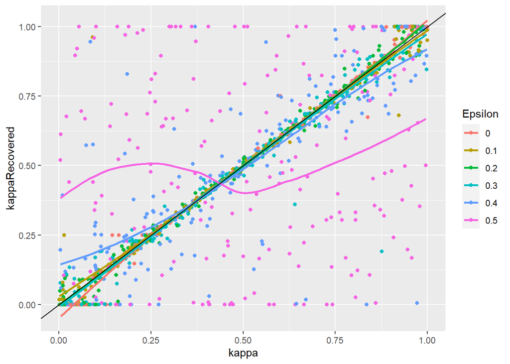

```r
library(ggplot2)
freeParameters$Epsilon = factor(freeParameters$epsilon)

qplot(data = freeParameters, x = kappa, y = kappaRecovered, color = Epsilon) + geom_smooth(se = F) + geom_abline()
```

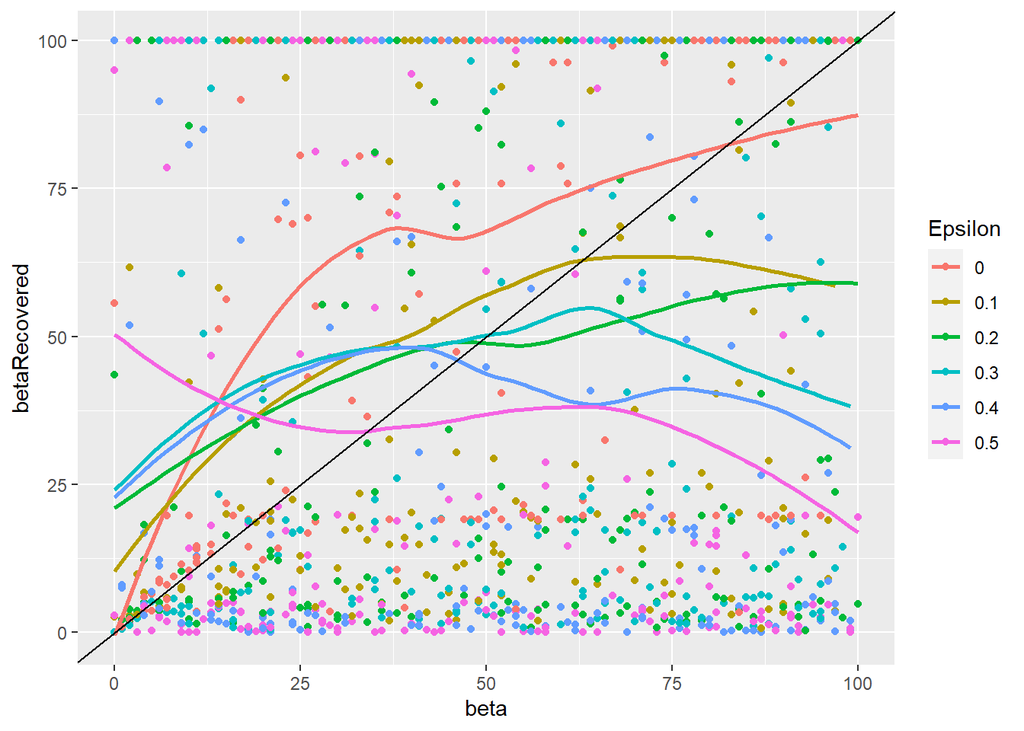

```r
qplot(data = freeParameters, x = beta, y = betaRecovered, color = Epsilon) + geom_smooth(se = F)+ geom_abline()
```

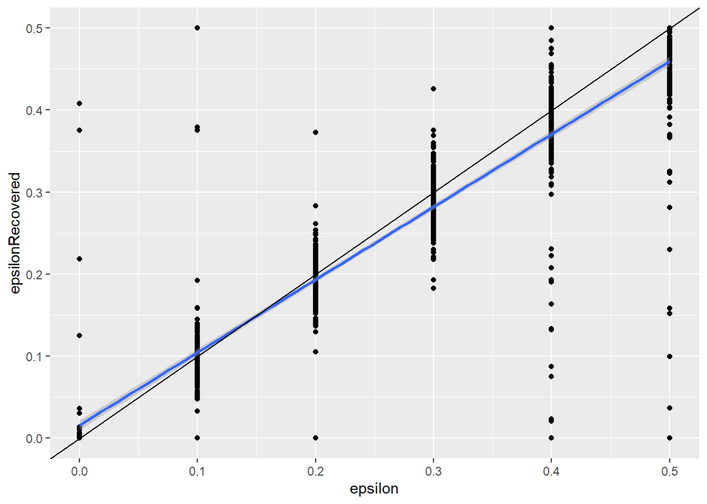

```r
qplot(data = freeParameters, x = epsilon, y = epsilonRecovered) + geom_smooth(method = 'lm') + geom_abline()
```

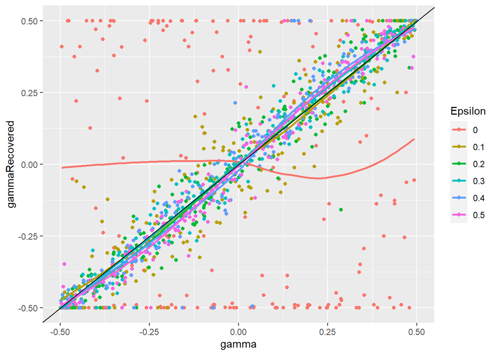

```r
qplot(data = freeParameters, x = gamma, y = gammaRecovered, color = Epsilon) + geom_smooth(se = F) + geom_abline()
```

The parameter that we are most interested in (i.e. kappa) is really reliable, even up to high (0.4) values of epsilon. At 0.5, it is completely random.

## 2.1 Recovering Free Parameters

Let’s get the trial data from participants. Data are stored in seperate mat files so we need to go through these to compile the data

```r
library(R.matlab)
parentfolder = 'C:/Users/DELL/Downloads/fMRI_choice_data/run'
included_subjects = list.files(paste(parentfolder, '1', sep = ''), full.names = F)
included_subjects = gsub('.mat', '', gsub('BC_1', '', included_subjects))

subjectData = data.frame()

grab_data = function(subject){
  if (sum(grepl(pattern = subject, x = list.files(paste(parentfolder, '2/', sep = ''), full.names = F))) == 0){
    return("skipping")
  }
  for (r in 1:2){
    datafile = paste(parentfolder, r, '/BC_', r, subject, '.mat', sep = '')
    temp = readMat(datafile)
    if (r == 1){
      choices = temp["choice"]
      df = data.frame(temp["trialinfo"])
      df = cbind(df[1:76, ], as.data.frame(choices)[1:76, ])
    } else {
      choices = temp["choice"]
      temp = data.frame(temp["trialinfo"])
      temp = cbind(temp[1:76, ], as.data.frame(choices)[1:76, ])
      df = rbind(df, temp) #some have duplicate values
    }
  }
  df[which(is.na(df[,11])), 11] = sample(c(1,2), size = sum(is.na(df[,11])), replace = T)
  df[, 10] = (df[, 10] * -1) + 2 # 1 is harm 0 is help now
  df[, 11] = (df[, 11] * -1) + 2 # 1 is self 0 is other now
  colnames(df) = c("trialNumber", "moneyLess", "moneyDifference", "moneyMore", "shocksLess", "shocksDifference", "shocksMore", "isLeft", "runNumber", "isSelf", "choseHarm")

  return(df)
}

generate_predictions = function(df, result){
  df$ProbHarm = 0
  Epsilon = result$par[5]
  Gamma = result$par[6]
  for (k in 1:length(df[,1])){
    shocksMore = df$shocksMore[k]
    shocksLess = df$shocksLess[k]
    moneyMore = df$moneyMore[k]
    moneyLess = df$moneyLess[k]
    isLeft = as.logical(df$isLeft[k])
    isSelf = as.logical(df$isSelf[k])
    if (isSelf) {Kappa = result$par[1]; Beta = result$par[3]} else {Kappa = result$par[2]; Beta = result$par[4]}

    # Just Added
    Utility = utility(Harm = harm(shocksMore, shocksLess),
                      Payout = payout(moneyMore, moneyLess),
                      kappa = Kappa)
    df$ProbHarm[k] = max(min(probability(Beta, Epsilon, Gamma, Utility, isLeft), 0.9999999999), 0.00000000001)
  }
  return(df)
}
```

So we’ve got a way to get all of the files that we need (per subject, per run), a function to extract the data, and function to generate predictions. We’ll also update the objective function to handle both conditions (and ensure that we provide the correct number of parameter arguments) in addition to providing some error handling to our optimization procedure.

```r
obj_function = function(params, df, optimMethod = "MLE") {
  Epsilon = params[5]
  Gamma = params[6]

  ProbHarm = vector('numeric', length(df[,1]))
  choices = as.numeric(df[, 11])
  for (k in 1:length(df[,1])){
    isLeft = as.logical(df[k, 8])
    isSelf = as.logical(df[k, 10])
    if (isSelf){Kappa = params[1]; Beta = params[3]} else {Kappa = params[2]; Beta = params[4]}
    moneyMore = as.numeric(df[k, 4])
    moneyLess = as.numeric(df[k, 2])
    shocksMore = as.numeric(df[k, 7])
    shocksLess = as.numeric(df[k, 5])

    Utility = utility(Harm = harm(shocksMore, shocksLess),
                      Payout = payout(moneyMore, moneyLess),
                      kappa = Kappa)
    ProbHarm[k] = max(min(probability(Beta, Epsilon, Gamma, Utility, isLeft), 0.9999999999), 0.00000000001)
  }
  if (optimMethod == "OLS"){
    return(sum((choices - ProbHarm)**2))
  } else if (optimMethod == "MLE"){
    return(-sum(choices * log(ProbHarm) + (1 - choices) * log(1 - ProbHarm)))
  }
}

initial_params = c(0.5, 0.5, 4, 4, 0.25, 0)
lower_bounds = c(0, 0, 0, 0, 0, -0.5)
upper_bounds = c(1, 1, 100, 100, 0.5, 0.5)

optimize = function(df){
  tryCatch({
    fmincon(obj_function, x0 = initial_params, lb = lower_bounds, ub = upper_bounds, df = df, optimMethod = "MLE")
  }, error = function(e){
    fmincon(obj_function, x0 = initial_params, lb = lower_bounds, ub = upper_bounds, df = df, optimMethod = "OLS")
  })
}
```

All of this allows us to Recover Free Parameters and Define Predicted Decisions

```r
for (i in 1:length(included_subjects)){
  df = grab_data(included_subjects[i])
  if (is.character(df)){next}

  result = optimize(df)

  df = generate_predictions(df, result)

  model_SS = sum((df$choseHarm - df$ProbHarm)**2)
  model_NLL = -2*sum(df$choseHarm * log(df$ProbHarm) + (1 - df$choseHarm) * log(1 - df$ProbHarm))

  subjectData[i, 1:9] = c(included_subjects[i], result$par[1], result$par[2], result$par[3], result$par[4], result$par[5], result$par[6],
                     model_SS, model_NLL)

  df = cbind(data.frame(SubjectID = rep(included_subjects[i], length(df$trialNumber))), df)
  if (i == 1) {trialData = df} else {trialData = rbind(trialData, df)}
}

colnames(subjectData) = c("subjectID",
                          "Kappa_Self", "Kappa_Other", "Beta_Self", "Beta_Other",
                          "Epsilon", "Gamma", "SS", "Deviance")
head(subjectData)
```

```
##     subjectID        Kappa_Self       Kappa_Other        Beta_Self
## 1 D1032709173 0.952268721090634 0.947280875263922 99.9999999999995
## 2 D1040210174 0.760596124426655 0.748858515421918 1.56608042316092
## 3 D1050310171 0.970270511518256  0.95458806309253 1.15618778148566
## 4 D1071110173 0.793243604668089 0.420892742532995   1.117083756542
## 5 D1081110174 0.370031694997518                 1  1.2293012770542
## 6 D1091610171 0.104254191733529 0.118974326985596 2.41130354079548
##          Beta_Other              Epsilon              Gamma               SS
## 1  1.41857893504978                    0  0.114645990918773 4.86062398934427
## 2               100   0.0161086331812476 0.0361931127585253 6.69383668275483
## 3   6.7592222680087 2.03009408575026e-17 -0.499784461548045 6.61820011896671
## 4  1.66694238852685  0.00964220588006764                0.5 11.5314783636129
## 5 0.715543964322503   0.0173036209436401                0.5 13.3546446454393
## 6  1.34153476990935                    0   0.47961537578324 7.78953718425064
##           Deviance
## 1 28.1541610710526
## 2 49.0251068470814
## 3 42.1741813091509
## 4 73.7177295005443
## 5 84.7479603526218
## 6 52.9836356894226
```

Okay, the subject level data looks good, how about the trial level data?

```r
head(trialData)
```

```
##     SubjectID trialNumber moneyLess moneyDifference moneyMore shocksLess
## 1 D1032709173           1      10.8             0.2      11.0         14
## 2 D1032709173           2       6.7             0.1       6.8          8
## 3 D1032709173           3       7.5             0.1       7.6          2
## 4 D1032709173           4       8.9             4.1      13.0          6
## 5 D1032709173           5       2.4             4.9       7.3          3
## 6 D1032709173           6      11.5             4.3      15.8          4
##   shocksDifference shocksMore isLeft runNumber isSelf choseHarm     ProbHarm
## 1                1         15      1         1      1         1 9.999994e-01
## 2                1          9      1         1      0         1 5.148938e-01
## 3               13         15      1         1      1         0 1.000000e-11
## 4                6         12      0         1      0         1 9.936997e-01
## 5               11         14      0         1      1         1 1.000000e+00
## 6                4          8      1         1      1         1 1.000000e+00
```

## 2.2 Compute Model Fit Index

We will calculate BIC as the model fit index because we are attempting to model the probabilistic nature of the data generation process.

```r
subjectData$BIC = as.numeric(subjectData$Deviance) + log(152) * 6
```

## 2.3 Identity the Best Model

```r
optimize = function(of, using, df){
  tryCatch({
    fmincon(of,
            x0 = initial_params[using], lb = lower_bounds[using], ub = upper_bounds[using], df = df, optimMethod = "MLE")
  }, error = function(e){
    fmincon(of, x0 = initial_params[using], lb = lower_bounds[using], ub = upper_bounds[using], df = df, optimMethod = "OLS")
  })
}

obj_functionNoGamma = function(params, df, optimMethod = "MLE") {
  Epsilon = params[5]
  Gamma = 0

  ProbHarm = vector('numeric', length(df[,1]))
  choices = as.numeric(df[, 11])
  for (k in 1:length(df[,1])){
    isLeft = as.logical(df[k, 8])
    isSelf = as.logical(df[k, 10])
    if (isSelf){Kappa = params[1]; Beta = params[3]} else {Kappa = params[2]; Beta = params[4]}
    moneyMore = as.numeric(df[k, 4])
    moneyLess = as.numeric(df[k, 2])
    shocksMore = as.numeric(df[k, 7])
    shocksLess = as.numeric(df[k, 5])

    Utility = utility(Harm = harm(shocksMore, shocksLess),
                      Payout = payout(moneyMore, moneyLess),
                      kappa = Kappa)
    ProbHarm[k] = max(min(probability(Beta, Epsilon, Gamma, Utility, isLeft),
                          0.9999999999), 0.00000000001)
  }
  if (optimMethod == "OLS"){
    return(sum((choices - ProbHarm)**2))
  } else if (optimMethod == "MLE"){
    return(-sum(choices * log(ProbHarm) + (1 - choices) * log(1 - ProbHarm)))
  }
}
obj_functionNoEpsilon = function(params, df, optimMethod = "MLE") {
  Epsilon = 0
  Gamma = 0

  ProbHarm = vector('numeric', length(df[,1]))
  choices = as.numeric(df[, 11])
  for (k in 1:length(df[,1])){
    isLeft = as.logical(df[k, 8])
    isSelf = as.logical(df[k, 10])
    if (isSelf){Kappa = params[1]; Beta = params[3]} else {Kappa = params[2]; Beta = params[4]}
    moneyMore = as.numeric(df[k, 4])
    moneyLess = as.numeric(df[k, 2])
    shocksMore = as.numeric(df[k, 7])
    shocksLess = as.numeric(df[k, 5])

    Utility = utility(Harm = harm(shocksMore, shocksLess),
                      Payout = payout(moneyMore, moneyLess),
                      kappa = Kappa)
    ProbHarm[k] = max(min(probability(Beta, Epsilon, Gamma, Utility, isLeft),
                          0.9999999999), 0.00000000001)
  }
  if (optimMethod == "OLS"){
    return(sum((choices - ProbHarm)**2))
  } else if (optimMethod == "MLE"){
    return(-sum(choices * log(ProbHarm) + (1 - choices) * log(1 - ProbHarm)))
  }
}
obj_functionNoConditions = function(params, df, optimMethod = "MLE") {
  Kappa = params[1]
  Beta = params[2]
  Epsilon = params[3]
  Gamma = params[4]

  ProbHarm = vector('numeric', length(df[,1]))
  choices = as.numeric(df[, 11])
  for (k in 1:length(df[,1])){
    isLeft = as.logical(df[k, 8])
    isSelf = as.logical(df[k, 10])
    moneyMore = as.numeric(df[k, 4])
    moneyLess = as.numeric(df[k, 2])
    shocksMore = as.numeric(df[k, 7])
    shocksLess = as.numeric(df[k, 5])

    Utility = utility(Harm = harm(shocksMore, shocksLess),
                      Payout = payout(moneyMore, moneyLess),
                      kappa = Kappa)
    ProbHarm[k] = max(min(probability(Beta, Epsilon, Gamma, Utility, isLeft),
                          0.9999999999), 0.00000000001)
  }
  if (optimMethod == "OLS"){
    return(sum((choices - ProbHarm)**2))
  } else if (optimMethod == "MLE"){
    return(-sum(choices * log(ProbHarm) + (1 - choices) * log(1 - ProbHarm)))
  }
}
obj_functionNoKappa = function(params, df, optimMethod = "MLE") {
  Kappa = 0
  Beta = 0
  Epsilon = 0.5
  Gamma = params[1]

  ProbHarm = vector('numeric', length(df[,1]))
  choices = as.numeric(df[, 11])
  for (k in 1:length(df[,1])){
    isLeft = as.logical(df[k, 8])
    isSelf = as.logical(df[k, 10])
    moneyMore = as.numeric(df[k, 4])
    moneyLess = as.numeric(df[k, 2])
    shocksMore = as.numeric(df[k, 7])
    shocksLess = as.numeric(df[k, 5])

    Utility = utility(Harm = harm(shocksMore, shocksLess),
                      Payout = payout(moneyMore, moneyLess),
                      kappa = Kappa)
    ProbHarm[k] = max(min(probability(Beta, Epsilon, Gamma, Utility, isLeft),
                          0.9999999999), 0.00000000001)
  }
  if (optimMethod == "OLS"){
    return(sum((choices - ProbHarm)**2))
  } else if (optimMethod == "MLE"){
    return(-sum(choices * log(ProbHarm) + (1 - choices) * log(1 - ProbHarm)))
  }
}
NoGamma = seq(1, 5)
NoEpsilon = seq(1, 4)
NoConditions = c(1, 3, 5, 6)
NoKappa = 6

altSubjectData = data.frame()
```

Now let’s Recover Free Parameters and Generate Predictions for this Model

```r
for (i in 1:length(included_subjects)){
  df = grab_data(included_subjects[i])
  if (is.character(df)){next}

  resultNoGamma = optimize(obj_functionNoGamma, NoGamma, df)
  resultNoEpsilon = optimize(obj_functionNoEpsilon, NoEpsilon, df)
  resultNoConditions = optimize(obj_functionNoConditions, NoConditions, df)
  resultNoKappa = optim(obj_functionNoKappa,par = initial_params[NoKappa], lower = lower_bounds[NoKappa], upper = upper_bounds[NoKappa], df = df, method = 'L-BFGS-B')

  dfNoGamma = generate_predictions(df, data.frame(par = c(resultNoGamma$par[1:5], 0)))
  dfNoEpsilon = generate_predictions(df, data.frame(par = c(resultNoEpsilon$par[1:4], 0, 0)))
  dfNoConditions = generate_predictions(df, data.frame(par = c(resultNoConditions$par[c(1, 1, 2, 2, 3, 4)])))
  dfNoKappa = generate_predictions(df, data.frame(par = c(0, 0, 0, 0, 0.5, resultNoKappa$par[1])))

  modelNG_SS = sum((dfNoGamma$choseHarm - dfNoGamma$ProbHarm)**2)
  modelNG_NLL = -2*sum(dfNoGamma$choseHarm * log(dfNoGamma$ProbHarm) + (1 - dfNoGamma$choseHarm) * log(1 - dfNoGamma$ProbHarm))
  modelNE_SS = sum((dfNoEpsilon$choseHarm - dfNoEpsilon$ProbHarm)**2)
  modelNE_NLL = -2*sum(dfNoEpsilon$choseHarm * log(dfNoEpsilon$ProbHarm) + (1 - dfNoEpsilon$choseHarm) * log(1 - dfNoEpsilon$ProbHarm))
  modelNC_SS = sum((dfNoConditions$choseHarm - dfNoConditions$ProbHarm)**2)
  modelNC_NLL = -2*sum(dfNoConditions$choseHarm * log(dfNoConditions$ProbHarm) + (1 - dfNoConditions$choseHarm) * log(1 - dfNoConditions$ProbHarm))
  modelNK_SS = sum((dfNoKappa$choseHarm - dfNoKappa$ProbHarm)**2)
  modelNK_NLL = -2*sum(dfNoKappa$choseHarm * log(dfNoKappa$ProbHarm) + (1 - dfNoKappa$choseHarm) * log(1 - dfNoKappa$ProbHarm))

  altSubjectData[i, 1:23] = c(included_subjects[i],
                              resultNoGamma$par[1], resultNoGamma$par[2], resultNoGamma$par[3], resultNoGamma$par[4], resultNoGamma$par[5],
                              resultNoEpsilon$par[1], resultNoEpsilon$par[2], resultNoEpsilon$par[3], resultNoEpsilon$par[4],
                              resultNoConditions$par[1], resultNoConditions$par[2], resultNoConditions$par[3], resultNoConditions$par[4],
                              resultNoKappa$par[1],
                              modelNG_SS, modelNG_NLL, modelNE_SS, modelNE_NLL, modelNC_SS, modelNC_NLL, modelNK_SS, modelNK_NLL)


  df = cbind(data.frame(SubjectID = rep(included_subjects[i], length(df$trialNumber))), df)
  df$ProbHarmNG = dfNoGamma$ProbHarm
  df$ProbHarmNE = dfNoEpsilon$ProbHarm
  df$ProbHarmNC = dfNoConditions$ProbHarm
  df$ProbHarmNK = dfNoKappa$ProbHarm
  if (i == 1) {altTrialData = df} else {altTrialData = rbind(altTrialData, df)}
}

colnames(altSubjectData) = c('SubjectID', 'KappaSelfM2', 'KappaOtherM2',
                             'BetaSelfM2', 'BetaOtherM2', 'EpsilonM2',
                             'KappaSelfM3', 'KappaOtherM3', 'BetaSelfM3',
                             'BetaOtherM3', 'KappaM4', 'BetaM4', 'EpsilonM4',
                             'GammaM4', 'GammaM5',
                             'SSM2', 'DevianceM2', 'SSM3', 'DevianceM3',
                             'SSM4', 'DevianceM4', 'SSM5', 'DevianceM5')

for (i in 2:ncol(altSubjectData)){
  altSubjectData[,i] = as.numeric(altSubjectData[,i])
}
head(altSubjectData)
```

```
##     SubjectID KappaSelfM2 KappaOtherM2 BetaSelfM2 BetaOtherM2    EpsilonM2
## 1 D1032709173  0.95226865    0.9997566 100.000000 100.0000000 1.315942e-02
## 2 D1040210174  0.76014423    0.7462081   1.507304   1.9996760 1.387779e-17
## 3 D1050310171  0.97467916    0.9546434   2.994818   6.8209974 7.956321e-03
## 4 D1071110173  0.79211376    0.4181040   1.107974   1.5805488 1.081766e-02
## 5 D1081110174  0.37197292    1.0000000   1.113968   0.7136887 1.629361e-02
## 6 D1091610171  0.09788503    0.1272274  99.475917   4.7919694 5.039027e-02
##   KappaSelfM3  KappaOtherM3  BetaSelfM3 BetaOtherM3   KappaM4     BetaM4
## 1   0.9522687  9.634295e-01 100.0000000   1.6204518 0.9796951 11.5306978
## 2   0.7601442  7.462080e-01   1.5072949   1.9996915 0.7531511  1.6991856
## 3   0.9702752  9.545831e-01   1.1560970   6.7594248 0.9634303  3.9804845
## 4   1.0000000 -2.301115e-17   0.0000000   0.2220313 0.5811365  0.4803621
## 5   0.3812302  1.000000e+00   0.7067574   0.6845228 0.6549876  0.2270424
## 6   0.1042547  1.189742e-01   2.4112928   1.3415350 0.1104511  2.6730574
##      EpsilonM4       GammaM4     GammaM5      SSM2 DevianceM2      SSM3
## 1 1.505659e-02  0.0009471058  0.00000000  1.974547   21.34742  4.244825
## 2 0.000000e+00  0.0799816252  0.01315786  8.213700   51.74977  8.213695
## 3 7.368681e-03  0.5000000000  0.00000000  6.296171   42.56880  6.618300
## 4 0.000000e+00  0.0044816778 -0.02631572 11.456893   74.71974 34.430734
## 5 2.081668e-17  0.0156527260  0.00000000 13.337505   86.71772 13.573384
## 6 9.588107e-03 -0.5000000000 -0.01973678  7.553888   60.79409  7.789538
##   DevianceM3      SSM4 DevianceM4     SSM5 DevianceM5
## 1   25.74883  4.907165   39.06723 38.00000   210.7167
## 2   51.74977  8.367127   52.28331 37.97368   210.6115
## 3   42.17418  6.247744   43.72576 38.00000   210.7167
## 4  190.20548 21.939365  130.74818 37.89474   210.2955
## 5   87.19298 30.130554  174.76681 38.00000   210.7167
## 6   52.98364  7.398256   49.76806 37.94079   210.4798
```

Let’s glance at the trial level data for these alternative models.

```r
head(altTrialData)
```

```
##     SubjectID trialNumber moneyLess moneyDifference moneyMore shocksLess
## 1 D1032709173           1      10.8             0.2      11.0         14
## 2 D1032709173           2       6.7             0.1       6.8          8
## 3 D1032709173           3       7.5             0.1       7.6          2
## 4 D1032709173           4       8.9             4.1      13.0          6
## 5 D1032709173           5       2.4             4.9       7.3          3
## 6 D1032709173           6      11.5             4.3      15.8          4
##   shocksDifference shocksMore isLeft runNumber isSelf choseHarm ProbHarmNG
## 1                1         15      1         1      1         1 0.98683996
## 2                1          9      1         1      0         1 0.98679517
## 3               13         15      1         1      1         0 0.01315942
## 4                6         12      0         1      0         1 0.98684058
## 5               11         14      0         1      1         1 0.98684058
## 6                4          8      1         1      1         1 0.98684058
##     ProbHarmNE ProbHarmNC ProbHarmNK
## 1 9.999994e-01  0.8718986        0.5
## 2 5.241957e-01  0.7037333        0.5
## 3 1.000000e-11  0.1397436        0.5
## 4 9.976367e-01  0.9849149        0.5
## 5 1.000000e+00  0.9849149        0.5
## 6 1.000000e+00  0.9849719        0.5
```

Now we can compute BIC for these models

```r
altSubjectData$BICM2 = as.numeric(altSubjectData$DevianceM2) + log(152) * 5
altSubjectData$BICM3 = as.numeric(altSubjectData$DevianceM3) + log(152) * 4
altSubjectData$BICM4 = as.numeric(altSubjectData$DevianceM4) + log(152) * 4
altSubjectData$BICM5 = as.numeric(altSubjectData$DevianceM5) + log(152) * 1
```

And now we can compare the BIC of all models

```r
modelBIC = c(sum(subjectData$BIC[-20]),
             sum(altSubjectData$BICM2[-20]),
             sum(altSubjectData$BICM3[-20]),
             sum(altSubjectData$BICM4[-20]),
             sum(altSubjectData$BICM5[-20]))
which(modelBIC == min(modelBIC))
```

```
## [1] 2
```

This analysis indicates that the best model has KappaSelf, BetaSelf, KappaOther, BetaOther, and Epsilon but not Gamma.

## 2.4 Validate the Best Model

First, let’s assess model performance at a basic level: we can look at prediction accuracy to begin

```r
sum(altTrialData$choseHarm == round(altTrialData$ProbHarmNG))/nrow(altTrialData)
```

```
## [1] 0.8990509
```

Now we can check assumptions: first linearity (we’ll do this across both choices)

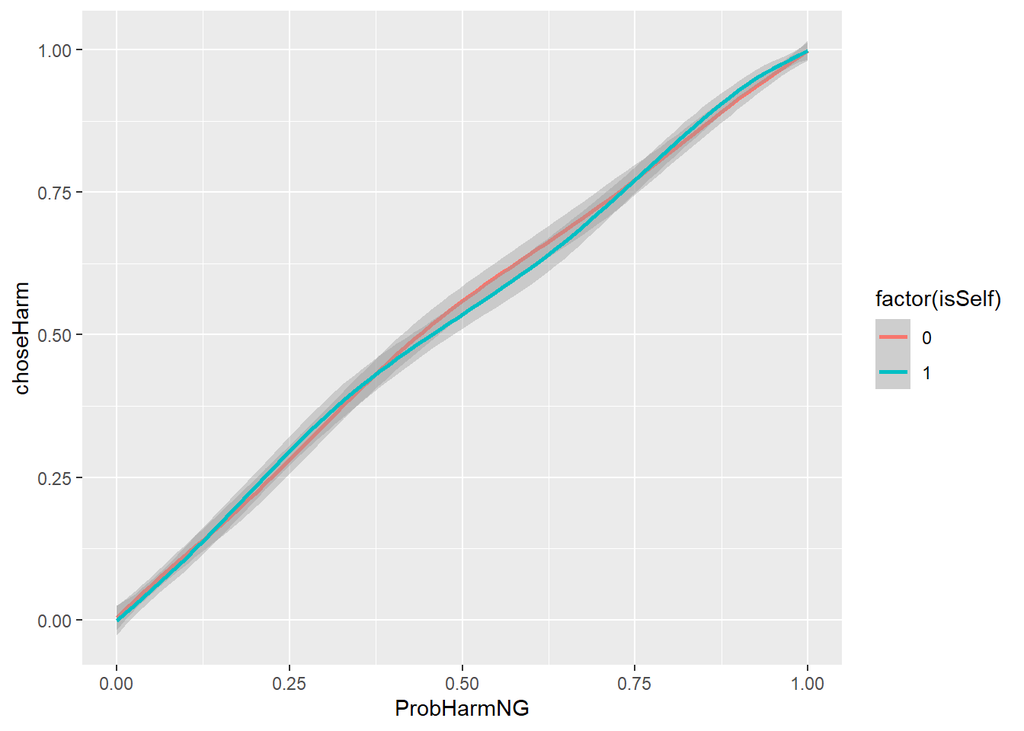

```r
ggplot(data = altTrialData) +
  geom_smooth(aes(x = ProbHarmNG, y = choseHarm, group = isSelf, color = factor(isSelf)))
```

Looks very good. Second, normality of error:

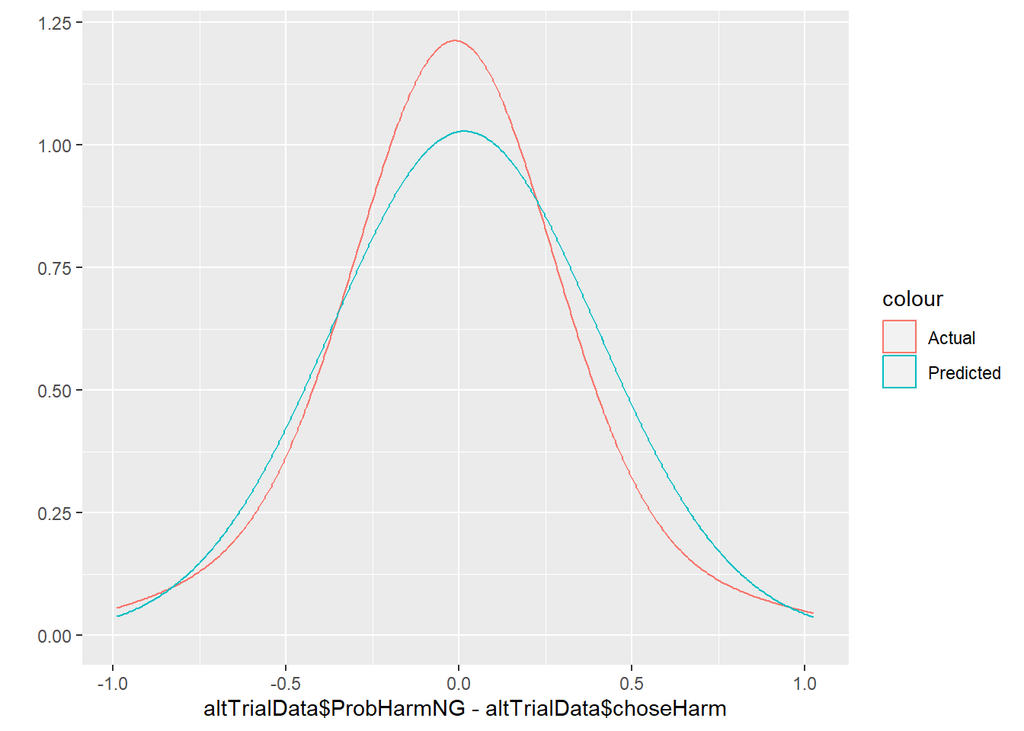

```r
normvals = rnorm(1000, mean = 0, sd = sd(altTrialData$ProbHarmNG - altTrialData$choseHarm))
qplot(x = altTrialData$ProbHarmNG - altTrialData$choseHarm, geom = 'density', bw = sd(altTrialData$ProbHarmNG - altTrialData$choseHarm), color = 'Actual') +
  geom_density(aes(x = normvals, color = 'Predicted'), bw = sd(altTrialData$ProbHarmNG - altTrialData$choseHarm))
```

Looks leptokurtic, but pretty normal for these kinds of model. Third we can examine homoscedasticity:

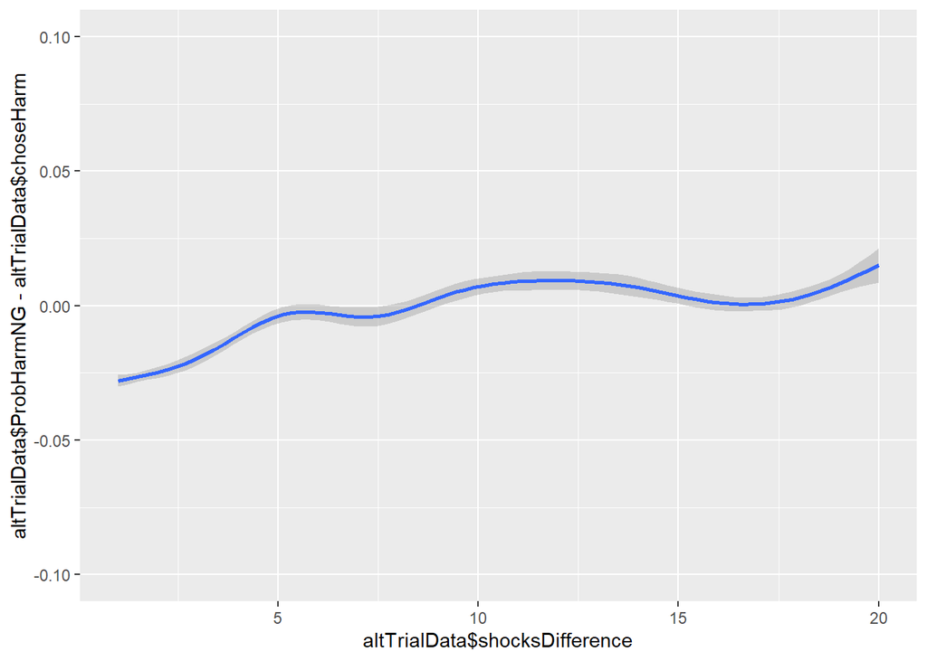

```r
qplot(x = altTrialData$shocksDifference, y = altTrialData$ProbHarmNG - altTrialData$choseHarm, geom = 'smooth')  + lims(y = c(-.1, .1))
```

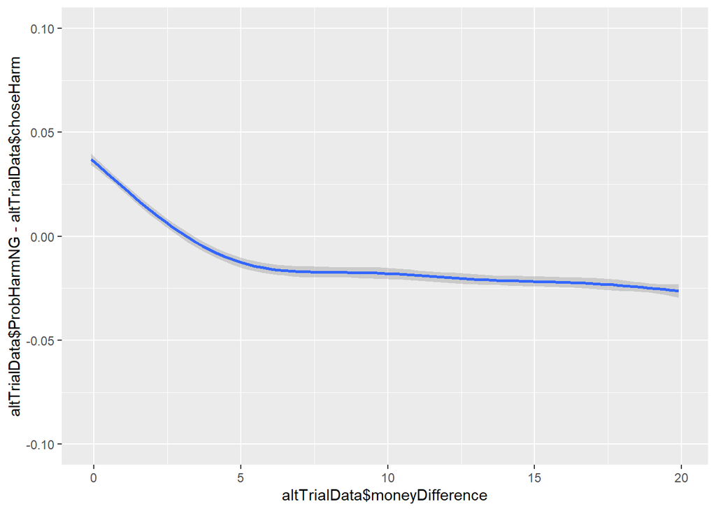

```r
qplot(x = altTrialData$moneyDifference, y = altTrialData$ProbHarmNG - altTrialData$choseHarm, geom = 'smooth')  + lims(y = c(-.1, .1))
```

Nice constant variance cloud across all X values. It seems that the model slightly overpredicts how much people will choose harm when the money difference is less that 2. And finally independence of error:

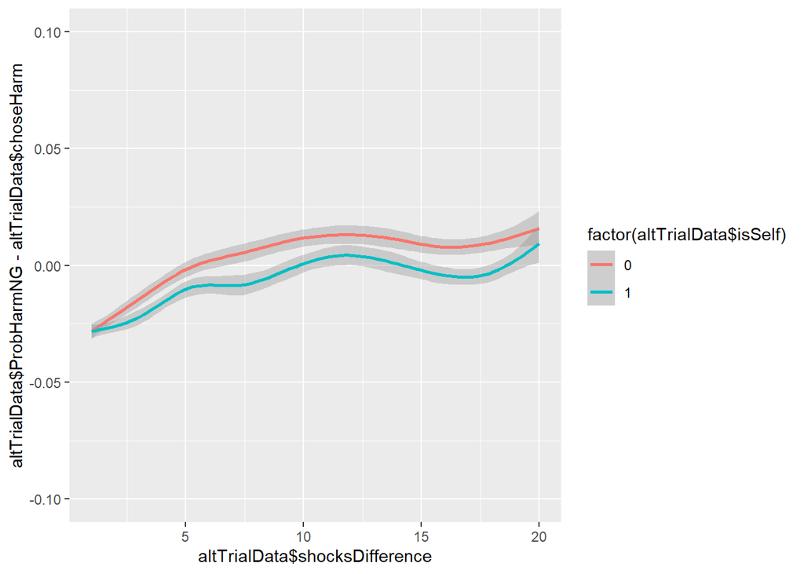

```r
qplot(x = altTrialData$shocksDifference, y = altTrialData$ProbHarmNG - altTrialData$choseHarm, color = factor(altTrialData$isSelf), geom = 'smooth') + lims(y = c(-.1,.1))
```

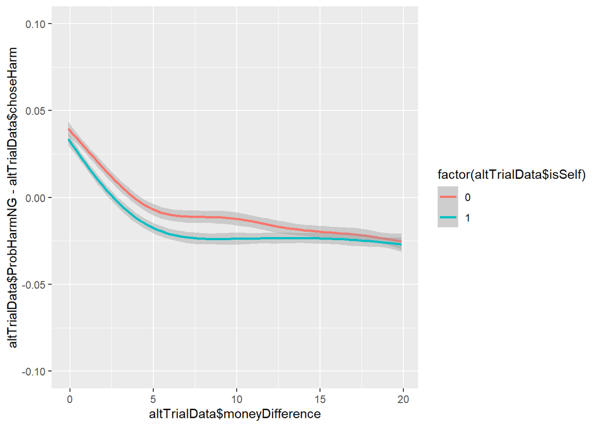

```r
qplot(x = altTrialData$moneyDifference, y = altTrialData$ProbHarmNG - altTrialData$choseHarm, color = factor(altTrialData$isSelf), geom = 'smooth') + lims(y = c(-.1,.1))
```

The model seems to slightly overpredict harm to the other player, but it’s a difference of less than 2% across most values of shock.

Let’s assess the independence: i.e. the extent to which our model captures all differences in choice behavior between different people:

```r
library(lme4)
library(MuMIn)
ris_model = glmer(data = altTrialData, choseHarm ~ ProbHarmNG + (1 + ProbHarmNG | SubjectID), family = "binomial")
```

```
## boundary (singular) fit: see help('isSingular')
```

```r
r.squaredGLMM(ris_model)
```

```
## Warning: 'r.squaredGLMM' now calculates a revised statistic. See the help page.
```

```
## Warning: the null model is correct only if all variables used by the original
## model remain unchanged.
```

```
## boundary (singular) fit: see help('isSingular')
```

```
##                   R2m       R2c
## theoretical 0.6794827 0.6838659
## delta       0.6360585 0.6401615
```

Singularity warning means that (most probably) the random slope is completely redundant: trying without.

```r
ri_model = glmer(data = altTrialData, choseHarm ~ ProbHarmNG + (1 | SubjectID), family = "binomial")
```

```
## boundary (singular) fit: see help('isSingular')
```

```r
r.squaredGLMM(ri_model)
```

```
## Warning: the null model is correct only if all variables used by the original
## model remain unchanged.
```

```
##                   R2m       R2c
## theoretical 0.6794520 0.6794520
## delta       0.6194109 0.6194109
```

Same issue, this is good. Let’s see about if there’s some unexplainied variance across conditions.

```r
ric_model = glmer(data = altTrialData, choseHarm ~ ProbHarmNG + isSelf + (1 | SubjectID), family = "binomial")
```

```
## boundary (singular) fit: see help('isSingular')
```

```r
r.squaredGLMM(ric_model)
```

```
##                   R2m       R2c
## theoretical 0.6794845 0.6794845
## delta       0.6194461 0.6194461
```

Good, finally, let’s compare the R-squared from these models to the one from a standard lm model.

```r
r.squaredLR(glm(data = altTrialData, choseHarm ~ ProbHarmNG, family = "binomial"))
```

```
## [1] 0.5517669
## attr(,"adj.r.squared")
## [1] 0.7538992
```

Pretty damn similar, very good! Let’s jump to fivefold validation

```r
fivefold = data.frame()
trialData$ProbHarm_ff = 0
adj = 1
for (i in 1:length(included_subjects)){
  df = grab_data(included_subjects[i])
  if (is.character(df)){adj = adj + 1; next}
  df$ProbHarm = 0

  order = sample(152)
  KSelf_ff = vector('numeric', length = 5)
  KOther_ff = vector('numeric', length = 5)
  BSelf_ff = vector('numeric', length = 5)
  BOther_ff = vector('numeric', length = 5)
  E_ff = vector('numeric', length = 5)
  Deviance_ff = 0
  df$Pred = 0
  for (z in 1:5){
    j = round((z - 1) * (152/5) + 1)
    n = round(z * (152/5))
    withheld = order[j:n]

    result_ff = optimize(obj_functionNoGamma, NoGamma, df[-withheld,])

    KSelf_ff[z] = result_ff$par[1]
    KOther_ff[z] = result_ff$par[2]
    BSelf_ff[z] = result_ff$par[3]
    BOther_ff[z] = result_ff$par[4]
    E_ff[z] = result_ff$par[5]
    df[withheld, ] = generate_predictions(df[withheld, ],
                                          data.frame(par =
                                                       c(result_ff$par[1:5],
                                                         0)))
  }
  Deviance_ff = -2*sum(df$choseHarm * log(df$ProbHarm) + (1 - df$choseHarm) * log(1 - df$ProbHarm))
  fivefold[i, 1:27] = c(included_subjects[i], Deviance_ff,
                        KSelf_ff, KOther_ff, BSelf_ff, BOther_ff, E_ff)
  j = (i-adj)*152 + 1; n = (i-adj + 1)*152
  trialData$ProbHarm_ff[j:n] = df$ProbHarm
}
colnames(fivefold) = c('SubjectID', 'Deviance',
                       'KS_F1', 'KS_F2', 'KS_F3', 'KS_F4', 'KS_F5',
                       'KO_F1','KO_F2','KO_F3','KO_F4','KO_F5',
                       'BS_F1', 'BS_F2', 'BS_F3', 'BS_F4', 'BS_F5',
                       'BO_F1','BO_F2','BO_F3','BO_F4','BO_F5',
                       'E_F1', 'E_F2', 'E_F3', 'E_F4', 'E_F5')
head(fivefold)
```

```
##     SubjectID         Deviance             KS_F1             KS_F2
## 1 D1032709173 31.1566901832346 0.952266699570411 0.961113430360818
## 2 D1040210174 59.9672516153579 0.777446383466438 0.801669424236663
## 3 D1050310171 71.7060745133965  0.99341565772409 0.977492794006675
## 4 D1071110173  94.676405645246 0.795819605710494 0.789034815820508
## 5 D1081110174 103.152349672025 0.347273430122135 0.378182348132825
## 6 D1091610171 80.2144910528215 0.122412242451099 0.103124247251605
##               KS_F3             KS_F4              KS_F5             KO_F1
## 1  0.95226877169175 0.952268622891635  0.950116116040479                 1
## 2 0.778513662510027 0.747193081079566   0.75051299491842 0.750087231658477
## 3 0.933859995886087 0.955336069738724  0.964597825018316 0.958471862979957
## 4 0.787130895500822 0.796430292816572  0.788768693136029 0.428422058713555
## 5 0.388304578384202 0.383821309040046  0.377498002974992 0.950399315453131
## 6 0.117040550482906 0.115595635054259 0.0769937274037651 0.138813746300175
##               KO_F2             KO_F3             KO_F4             KO_F5
```

[output cut: 34 more lines]

Now we can check the model accuracy:

```r
sum(round(trialData$ProbHarm_ff) == trialData$choseHarm)/nrow(trialData)
```

```
## [1] 0.8802847
```

Only lost about 2% in accuracy which is quite reassuring. And test it against the normally recovered model:

```r
fivefold$BIC = as.numeric(fivefold$Deviance) + log(152) * 5
t.test(fivefold$BIC[-20], altSubjectData$BICM2[-20], paired = T)
```

```
##
##  Paired t-test
##
## data:  fivefold$BIC[-20] and altSubjectData$BICM2[-20]
## t = 7.7615, df = 60, p-value = 1.252e-10
## alternative hypothesis: true mean difference is not equal to 0
## 95 percent confidence interval:
##  21.61244 36.62025
## sample estimates:
## mean difference
##        29.11634
```

It’s worse, but that’s okay considering this only constitutes 2% accuracy. And to assess the reliability, we can compute cosine similiarity:

```r
library(lsa)
cosines = vector('numeric', length = 60)
for (i in 1:5){
  cosines[i] = cosine(as.numeric(subjectData$Kappa_Self[-20]), as.numeric(fivefold[-20, (i + 2)]))
  cosines[(i+5)] = cosine(as.numeric(subjectData$Kappa_Other[-20]), as.numeric(fivefold[-20, (i + 7)]))
  cosines[(i+10)] = cosine(as.numeric(subjectData$Beta_Self[-20]), as.numeric(fivefold[-20, (i + 12)]))
  cosines[(i+15)] = cosine(as.numeric(subjectData$Beta_Other[-20]), as.numeric(fivefold[-20, (i + 17)]))
  cosines[(i+20)] = cosine(as.numeric(subjectData$Epsilon[-20]), as.numeric(fivefold[-20, (i + 22)]))
}
```

And compute the averages per parameter: first kappa self.

```r
mean(cosines[1:5])
```

```
## [1] 0.9942519
```

Very close to 1, nice! Then kappa other.

```r
mean(cosines[6:10])
```

```
## [1] 0.9900576
```

Also pretty reasonable. Then Beta self

```r
mean(cosines[11:15])
```

```
## [1] 0.6560343
```

Not good at all. Okay, now Beta Other

```r
mean(cosines[16:20])
```

```
## [1] 0.4135783
```

Again, pretty poor. Finally Epsilon

```r
mean(cosines[21:25])
```

```
## [1] 0.8874114
```

Better.

## 3.1 Compare Models

Let’s first see if the best model (all parameters except bias for left/right) outperforms the model with gamma.

```r
t.test(altSubjectData$BICM2, subjectData$BIC, paired = T)
```

```
##
##  Paired t-test
##
## data:  altSubjectData$BICM2 and subjectData$BIC
## t = -4.3604, df = 60, p-value = 5.177e-05
## alternative hypothesis: true mean difference is not equal to 0
## 95 percent confidence interval:
##  -5.151667 -1.911493
## sample estimates:
## mean difference
##        -3.53158
```

```r
t.test(altSubjectData$BICM2, altSubjectData$BICM3, paired = T)
```

```
##
##  Paired t-test
##
## data:  altSubjectData$BICM2 and altSubjectData$BICM3
## t = -1.3037, df = 60, p-value = 0.1973
## alternative hypothesis: true mean difference is not equal to 0
## 95 percent confidence interval:
##  -9.954454  2.098768
## sample estimates:
## mean difference
##       -3.927843
```

Not significantly better. But note here that we’re comparing the simpler model with bias to the more complex model without bias. Let’s compare apples to apples shall we:

```r
t.test(subjectData$BIC, altSubjectData$BICM3, paired = T)
```

```
##
##  Paired t-test
##
## data:  subjectData$BIC and altSubjectData$BICM3
## t = -0.1201, df = 60, p-value = 0.9048
## alternative hypothesis: true mean difference is not equal to 0
## 95 percent confidence interval:
##  -6.996377  6.203852
## sample estimates:
## mean difference
##      -0.3962627
```

```r
t.test(altSubjectData$BICM2, altSubjectData$BICM4, paired = T)
```

```
##
##  Paired t-test
##
## data:  altSubjectData$BICM2 and altSubjectData$BICM4
## t = -3.4759, df = 60, p-value = 0.0009527
## alternative hypothesis: true mean difference is not equal to 0
## 95 percent confidence interval:
##  -28.430660  -7.660756
## sample estimates:
## mean difference
##       -18.04571
```

Yes, and the one which only distinguishes between left and right?

```r
t.test(altSubjectData$BICM2, altSubjectData$BICM5, paired = T)
```

```
##
##  Paired t-test
##
## data:  altSubjectData$BICM2 and altSubjectData$BICM5
## t = -24.963, df = 60, p-value < 2.2e-16
## alternative hypothesis: true mean difference is not equal to 0
## 95 percent confidence interval:
##  -124.6855 -106.1855
## sample estimates:
## mean difference
##       -115.4355
```

Yes. Okay all done here.

## 3.2 Test Modulatory Hypotheses

```r
t.test(altSubjectData$KappaSelfM2[-20], altSubjectData$KappaOtherM2[-20],
       paired = T)
```

```
##
##  Paired t-test
##
## data:  altSubjectData$KappaSelfM2[-20] and altSubjectData$KappaOtherM2[-20]
## t = 3.5359, df = 60, p-value = 0.0007902
## alternative hypothesis: true mean difference is not equal to 0
## 95 percent confidence interval:
##  0.05103953 0.18400650
## sample estimates:
## mean difference
##        0.117523
```

Self interest is much higher in the self versus the other condition. But, crucially, this should be a follow-up based on the initial analysis showing that conditions elicit different behavior.

## 3.3 Test for Individual Differences

Let’s first recover parameters over the whole dataset and we can assess how accurate it is

```r
resultNID = fmincon(obj_functionNoGamma,
                    x0 = initial_params[NoGamma],
                    lb = lower_bounds[NoGamma], ub = upper_bounds[NoGamma],
                    df = trialData, optimMethod = "MLE")
resultNID = data.frame(par = c(resultNID$par, 0))
dfNID = generate_predictions(trialData[, 2:12], resultNID)
sum(dfNID$choseHarm == round(dfNID$ProbHarm))/nrow(dfNID)
```

```
## [1] 0.3683132
```

Not very good. This isn’t surprising given that people often have very different preferences. Now let’s test for individual differences.

```r
altSubjectData$Deviance_NID = 0

for (i in 1:length(included_subjects)){
  trials = which(included_subjects[i] == trialData$SubjectID)
  df = trialData[trials, ]
  altSubjectData$Deviance_NID[i] =
    -2*sum(df$Chose1 * log(as.numeric(df$Prob1_NID)) + (1 - df$Chose1) * log(1 - as.numeric(df$Prob1_NID)))
}

altSubjectData$BIC_NID =
  as.numeric(altSubjectData$Deviance_NID) + log(65) * 6/(length(included_subjects))

t.test(altSubjectData$BICM2[-20], altSubjectData$BIC_NID[-20], paired = T)
```

```
##
##  Paired t-test
##
## data:  altSubjectData$BICM2[-20] and altSubjectData$BIC_NID[-20]
## t = 21.642, df = 60, p-value < 2.2e-16
## alternative hypothesis: true mean difference is not equal to 0
## 95 percent confidence interval:
##   90.35671 108.76047
## sample estimates:
## mean difference
##        99.55859
```

```r
which(modelBIC > sum(altSubjectData$BIC_NID))
```

```
## [1] 1 2 3 4 5
```